# metabolmics data analysis on breast cancer

sara yusuf

2024-02-16

A total of 27 patients with BC and 30 healthy control subjects were recruited at The Department of Thyroid and Breast Surgery at The Nanxishan Hospital of Guangxi Zhuang Autonomous Region (Guilin, China) before surgery and/or chemotherapy. The study protocol was approved by The Institutional Review Board of the Clinical Research Ethics Committee of Guilin Hospital, and written informed consent was obtained from each subject. The inclusion criteria for patient recruitment was as follows: >18 years old, histologically confirmed BC, no metabolic disease and no previous anticancer treatment. For healthy individuals, there were no abnormalities on their blood tests, physical examinations nor in any imaging studies.

dataset resource: https://www.ebi.ac.uk/metabolights/editor/MTBLS8920/descriptors

```r
library(dplyr)
```

```r
library(corrplot)
library(ggplot2)
library(tidyverse)
library(impute)
library(impute)
library(limma)
library(enrichR)
library(ggpubr)
library(EnhancedVolcano)
library(RColorBrewer)
library(ComplexHeatmap)
library(vegan)
library(cluster)
library(factoextra)
library(gridExtra)
mytheme=theme(
        plot.title = element_text(hjust = 0.5,size=30,face = "bold"),
        axis.text.x = element_text( size = 15, angle = 45, hjust = .5, vjust = 0.5, face = "plain"),
        axis.text.y = element_text( size = 15, angle = 0, hjust = 1, vjust = 0, face = "plain"),
        axis.title.x = element_text( size = 20, angle = 0, hjust = .5, vjust = 0, face = "bold"),
        axis.title.y = element_text( size = 20, angle = 90, hjust = .5, vjust = .5, face = "bold"),
        #legend.title=element_text(size=20),
        legend.title=element_blank(), # remove legend title name
        legend.text = element_text(size=15,face="plain"),
        strip.text = element_text(size = 15,face="plain") ,
        legend.position="right",

        # for transparent background
        panel.background = element_rect(fill = "transparent"), # bg of the panel
        plot.background = element_rect(fill = "transparent", color = NA), # bg of the plotge
        panel.grid.major = element_blank(), # get rid of major grid
        panel.grid.minor = element_blank(), # get rid of minor grid
        legend.background = element_rect(fill = "transparent"), # get rid of legend bg
        legend.box.background = element_rect(fill = "transparent"), # get rid of legend panel bg
        axis.line = element_line(colour = "black") # adding a black line for x and y axis
)
```

read the input data and the metadata

```r
#library(readr)
metabolites =  read.delim("C:/Users/saraa/Desktop/COMP_BIO/moda/MTBLS8920_138219_compressed_files BREAST CANCER/m_MTBLS8920_LC-MS_positive_hilic_metabolite_profiling_v2_maf.tsv", header = T , na = "NA")
```

```r
pheno =  read_delim("c:/Users/saraa/Desktop/COMP_BIO/moda/MTBLS8920_138219_compressed_files BREAST CANCER/s_MTBLS8920.txt",
    delim = "\t", escape_double = FALSE,
    trim_ws = TRUE)
```

```
## ──────────────────────────────────────────────────────── Delimiter: "\t" chr
## (13): Source Name, Characteristics[Organism], Term Source REF...3, Term ... lgl
## (5): Characteristics[Variant], Term Source REF...9, Term Accession Numb...
```

```r
pheno = pheno %>%
  filter( !grepl('QC', `Source Name`))%>%
  select(`Sample Name`, `Factor Value[Disease]`)
```

let us do some exploration!

```r
class(metabolites)
```

```
## [1] "data.frame"
```

```r
metabolites[,1]
```

[output not shown]

[output cut: 84 more lines]

```r
head(metabolites)
```

```
##   database_identifier chemical_formula
## 1         CHEBI:28619           C3H5NO
## 2         CHEBI:17401       C6H18O24P6
## 3         CHEBI:35807          C2H6N2O
## 4         CHEBI:41879        C22H29FO5
## 5         CHEBI:19092            C4H7N
## 6        CHEBI:175520         C27H32O5
##                                                                                                 smiles
## 1                                                                                            MTBLS6894
## 2
## 3                                                                                             CN(C)N=O
## 4 C1=CC(C=C2[C@]1([C@@]3([C@@](CC2)([C@]4([C@](C[C@@H]3O)([C@]([C@@H](C4)C)(C(CO)=O)O)C)[H])[H])F)C)=O
## 5                                                                                             C1CC=NC1
## 6                               O1C[C@](CC=2C1=CC(OC)=C(C2OC)CC=C(C)C)(C3=C4OC(C=CC4=C(O)C=C3)(C)C)[H]
##                                                                                                                                                                                                                            inchi
```

[output cut: 111 more lines]

```r
metabolites = metabolites%>%
  select(-c(database_identifier:inchi))%>%
  select(-c(mass_to_charge : smallmolecule_abundance_std_error_sub
))
```

```r
data = as.matrix(metabolites)
```

```r
class(data)
```

```
## [1] "matrix" "array"
```

```r
colnames(data)
```

```
##  [1] "metabolite_identification" "Breast_1"
##  [3] "Breast_10"                 "Breast_11"
##  [5] "Breast_12"                 "Breast_13"
##  [7] "Breast_14"                 "Breast_15"
##  [9] "Breast_16"                 "Breast_17"
## [11] "Breast_18"                 "Breast_19"
## [13] "Breast_2"                  "Breast_20"
## [15] "Breast_21"                 "Breast_22"
## [17] "Breast_23"                 "Breast_24"
## [19] "Breast_25"                 "Breast_26"
## [21] "Breast_27"                 "Breast_28"
## [23] "Breast_3"                  "Breast_4"
## [25] "Breast_5"                  "Breast_7"
## [27] "Breast_8"                  "Breast_9"
## [29] "control_1"                 "control_10"
```

[output cut: 18 more lines]

```r
data = data%>%
  data.frame%>%
 select(metabolite_identification:control_9)
```

```r
data = apply(data,2 , as.numeric)
rownames(data) = metabolites$metabolite_identification
```

```r
dim(data)
```

```
## [1] 493  58
```

```r
head(pheno)
```

```
## # A tibble: 6 × 2
##   `Sample Name` `Factor Value[Disease]`
##   <chr>         <chr>
## 1 Breast_1      breast cancer
## 2 Breast_10     breast cancer
## 3 Breast_11     breast cancer
## 4 Breast_12     breast cancer
## 5 Breast_13     breast cancer
## 6 Breast_14     breast cancer
```

```r
str(pheno)
```

```
## tibble [57 × 2] (S3: tbl_df/tbl/data.frame)
##  $ Sample Name          : chr [1:57] "Breast_1" "Breast_10" "Breast_11" "Breast_12" ...
##  $ Factor Value[Disease]: chr [1:57] "breast cancer" "breast cancer" "breast cancer" "breast cancer" ...
```

```r
table(pheno$"Factor Value[Disease]")
```

```
##
##   breast cancer healthy control
##              27              30
```

```r
library(data.table)
 setnames(pheno, old = "Factor Value[Disease]",
    new = c("condition"))
```

```r
pheno$condition[pheno$condition == 'breast cancer'] = 'cancer'
pheno$condition[pheno$condition == 'healthy control'] = 'control'
```

```r
dim(pheno)
```

```
## [1] 57  2
```

```r
sum(is.na((data)))
```

```
## [1] 493
```

calculate variance and remove the constant columns

```r
varCol=apply(data, 2, var, na.rm = T)
```

```r
sum(is.na(varCol))
```

```
## [1] 1
```

```r
constCol = varCol == 0 | is.na(varCol)
```

```r
sum(constCol)
```

```
## [1] 1
```

```r
data = data[, !constCol]
dim(data)
```

```
## [1] 493  57
```

filter the columns with missingness rate higher than 70%

```r
missingness_rate=apply(is.na(data), 2, sum)/nrow(data) *100
max(missingness_rate)
```

```
## [1] 0
```

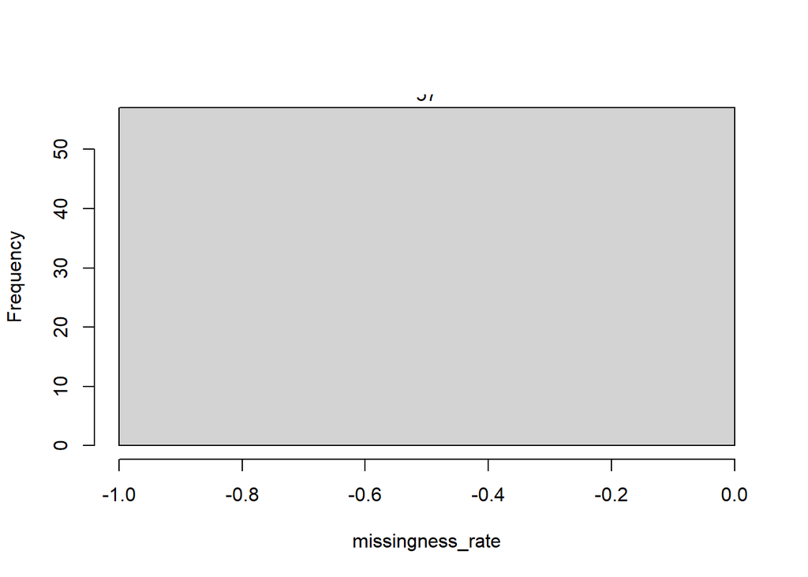

```r
h=hist(missingness_rate,breaks=10,
main="",
xlab="missingness_rate")
text(h$mids,h$counts,labels=h$counts, adj=c(0.5, -0.5))
```

```r
data.filt=data[,missingness_rate < 70]
dim(data.filt)
```

```
## [1] 493  57
```

```r
sum(is.infinite(data))
```

```
## [1] 0
```

transformation scaling and standarzation

```r
data.logged = log2(data+1 )
```

```r
sum(is.infinite(data.logged))
```

```
## [1] 0
```

```r
write.csv(data.logged , "DM_data_preprocessed.csv")
```

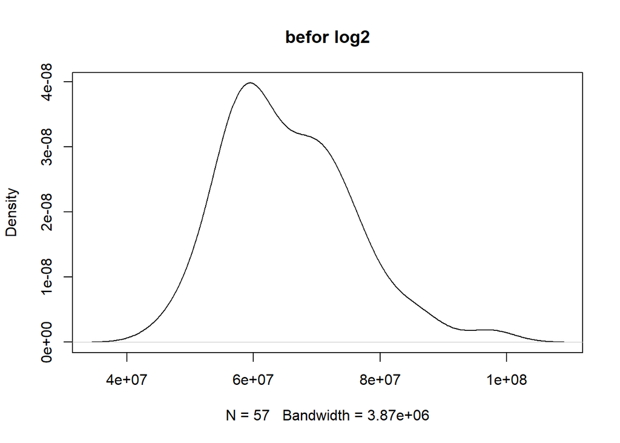

```r
plot(density(apply(data, 2, mean, na.rm = TRUE)),main='befor log2')
```

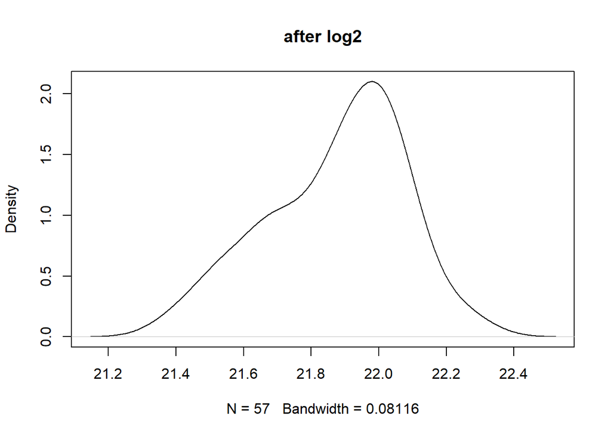

```r
plot(density(apply(data.logged, 2, mean, na.rm = TRUE)),main='after log2')
```

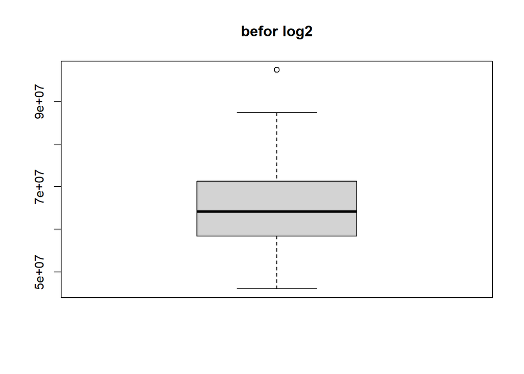

```r
boxplot(apply(data, 2, mean, na.rm = TRUE),main='befor log2')
```

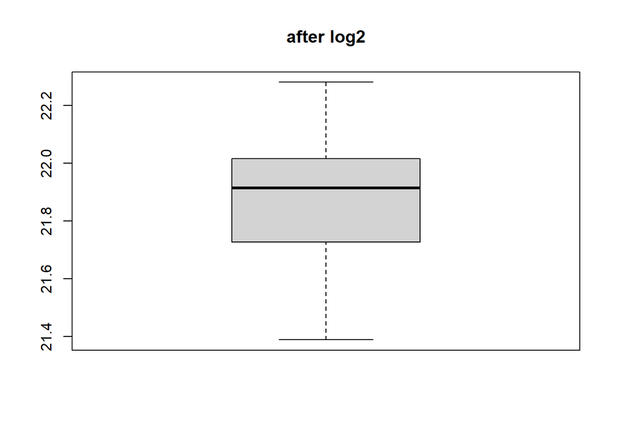

```r
boxplot(apply(data.logged, 2, mean, na.rm = TRUE),main='after log2')
```

colinearity check

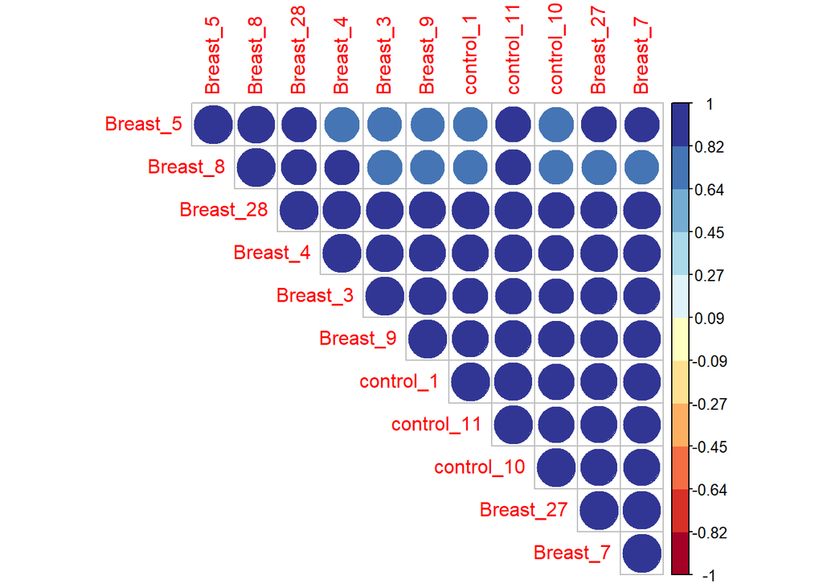

```r
cor = cor(data[,20:30])
corrplot(cor, type="upper", order="hclust" , col=brewer.pal(n=60, name="RdYlBu" ))
```

ensure all samples are matched between the data set and the metadata

```r
pheno = data.frame(pheno)
```

```r
colnames(data)
```

```
##  [1] "Breast_1"   "Breast_10"  "Breast_11"  "Breast_12"  "Breast_13"
##  [6] "Breast_14"  "Breast_15"  "Breast_16"  "Breast_17"  "Breast_18"
## [11] "Breast_19"  "Breast_2"   "Breast_20"  "Breast_21"  "Breast_22"
## [16] "Breast_23"  "Breast_24"  "Breast_25"  "Breast_26"  "Breast_27"
## [21] "Breast_28"  "Breast_3"   "Breast_4"   "Breast_5"   "Breast_7"
## [26] "Breast_8"   "Breast_9"   "control_1"  "control_10" "control_11"
## [31] "control_12" "control_13" "control_14" "control_15" "control_16"
## [36] "control_17" "control_18" "control_19" "control_2"  "control_20"
## [41] "control_21" "control_22" "control_23" "control_24" "control_25"
## [46] "control_26" "control_27" "control_28" "control_29" "control_3"
## [51] "control_30" "control_4"  "control_5"  "control_6"  "control_7"
## [56] "control_8"  "control_9"
```

```r
rownames(pheno) = colnames(data)
```

```r
all(rownames(pheno) %in% colnames(data))
```

```
## [1] TRUE
```

```r
data = data[ , colnames(data) %in% rownames(pheno) ]
```

```r
dim(pheno)
```

```
## [1] 57  2
```

```r
dim(data)
```

```
## [1] 493  57
```

perform principal component analysis

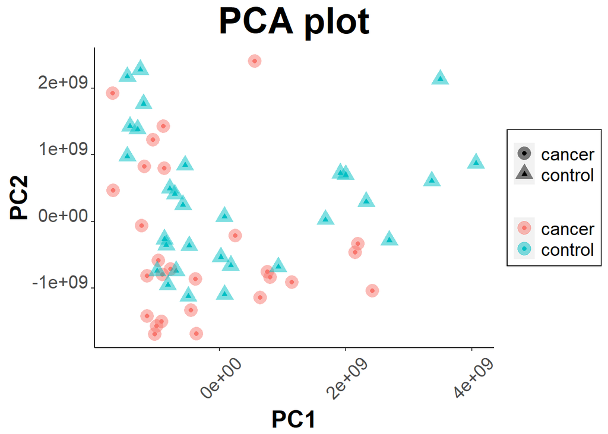

```r
pca = prcomp(t(data))
df_out = as.data.frame(pca$x)
ggplot(df_out,aes(x=PC1,y=PC2,color=pheno$condition,shape=pheno$condition ))+
geom_point()+ggtitle("PCA plot")+labs(color='')+
  geom_point(size=5,alpha=0.5)+ mytheme
```

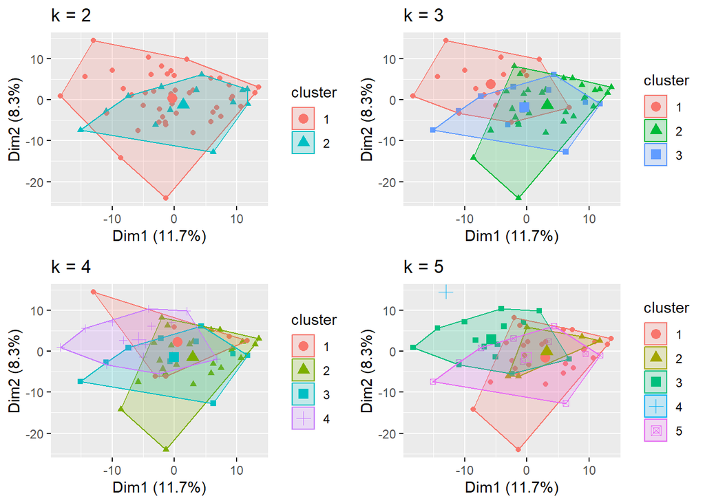

```r
kmeans2 = kmeans(t(data), centers = 2, nstart = 25)
kmeans3 = kmeans(t(data), centers = 3, nstart = 25)
kmeans4 = kmeans(t(data), centers = 4, nstart = 25)
kmeans5 = kmeans(t(data), centers = 5, nstart = 25)
 #Comparing the Plots
plot1 = fviz_cluster(kmeans2, geom = "point", data = t(data)) + ggtitle("k = 2")
plot2 = fviz_cluster(kmeans3, geom = "point", data = t(data)) + ggtitle("k = 3")
plot3 = fviz_cluster(kmeans4, geom = "point", data = t(data)) + ggtitle("k = 4")
plot4 = fviz_cluster(kmeans5, geom = "point", data = t(data)) + ggtitle("k = 5")
grid.arrange(plot1, plot2, plot3, plot4, nrow = 2)
```

```r
library(useful)
```

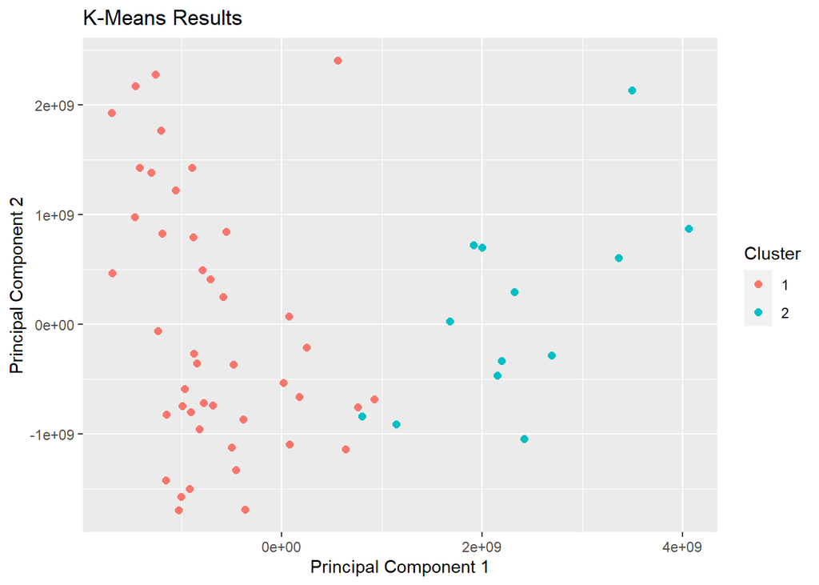

```r
plot(kmeans2, data=t(data))
```